# Species distribution modeling for mink in Ohio

[figure not shown]

```r
plot(studyArea[[14]],main="Precipitation of driest month")
plot(Ohio,add=T)
```

[figure not shown]

```r
plot(studyArea[[9]],main="Mean temperature of driest quarter")
plot(Ohio,add=T)
```

[figure not shown]

```r
plot(studyArea[[11]],main="Mean Temperature of Coldest Quarter")
plot(Ohio,add=T)
```

[figure not shown]

```r
plot(studyArea[[4]],main="Temperature Seasonality (standard deviation ×100)")
plot(Ohio,add=T)
```

[figure not shown]

```r
plot(studyArea[[6]],main="Min Temperature of Coldest Month")
plot(Ohio,add=T)
```

[figure not shown]

```r
plot(studyArea[[2]],main="Mean Diurnal Range (Mean of monthly (max temp - min temp))")
plot(Ohio,add=T)
```

#### 3. Prepare to run MaxENT

We will include some background points in our analysis. The code below specifies that we randomly pick 500 points across our study area.

```r
set.seed(1)

bg <- spatSample(
  studyArea,
  size = 500,
  method = "random",
  na.rm = TRUE,
  as.points = TRUE
)
```

Next we divide our data into training and test sets, and combine our background and training data.

```r
set.seed(1)

idx <- sample(1:nrow(mink_vect), nrow(mink_vect) * 0.5)

mink_train <- mink_vect[idx]
mink_test  <- mink_vect[-idx]

p <- extract(clim, mink_train)
a <- extract(clim, bg)

# remove ID column
p <- p[,-1]
a <- a[,-1]

# combine
X <- rbind(p, a)

# response vector
y <- c(rep(1, nrow(p)), rep(0, nrow(a)))
```

#### 4. Fit MaxENT and make predictions

Finally, we’re ready to run our ENM model! Note that several modeling choices have been made. Once the model is fit, we plot our predictions.

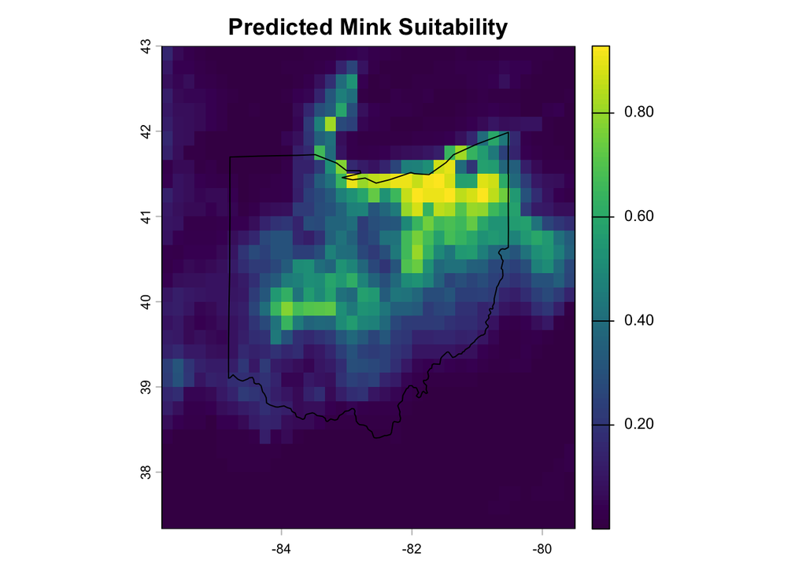

```r
# run MaxENT
mod <- maxnet(
  p = y,
  data = X,
  f = maxnet.formula(y, X, classes = "lqph")  # linear, quadratic, product, hinge
)

# make predictions
pred <- predict(studyArea, mod, type = "cloglog")

plot(pred, main = "Predicted Mink Suitability")
plot(Ohio, add = TRUE)
points(geom(mink_vect), pch = 20)
```

#### 5. Evaluate predictions

We can evaluate the model using our test data. This is an important step to calibrate how well our model works for data that it was not trained on. We want the Area Under the Curve (AUC) to be as large as possible.

```r
# extract test data
p_test <- extract(clim, mink_test)[,-1]
a_test <- extract(clim, bg)[,-1]

test_data <- rbind(p_test, a_test)
test_labels <- c(rep(1, nrow(p_test)), rep(0, nrow(a_test)))

# predictions
pred_vals <- predict(mod, test_data, type = "cloglog")

# simple AUC
pred_vals <- as.vector(pred_vals)
auc(test_labels, pred_vals)
```

```
## Area under the curve: 0.9336
```

#### 6. Assess variable importance

We can use a permutation approach to assess variable importance. We shuffle the values of one variable and see how much predictions worsen (by looking at AUC). The larger the drop, the more important the variable. Values close to 0 indicate that the variable is not very important.

```r
perm_importance <- function(model, X, y) {
  baseline <- predict(model, X, type = "cloglog")

  baseline_auc <- pROC::auc(y, as.vector(baseline))

  vars <- colnames(X)
  importance <- numeric(length(vars))

  for (i in seq_along(vars)) {
    X_perm <- X
    X_perm[, i] <- sample(X_perm[, i])  # shuffle

    pred_perm <- predict(model, X_perm, type = "cloglog")
    auc_perm <- pROC::auc(y, as.vector(pred_perm))

    importance[i] <- baseline_auc - auc_perm
  }

  names(importance) <- vars
  return(sort(importance, decreasing = TRUE))
}

library(pROC)

imp <- perm_importance(mod, X, y)
print(imp)
```

```
## wc2.1_10m_bio_14  wc2.1_10m_bio_4  wc2.1_10m_bio_7  wc2.1_10m_bio_3
##     1.235667e-01     1.086333e-01     9.581111e-02     8.816667e-02
## wc2.1_10m_bio_13  wc2.1_10m_bio_9  wc2.1_10m_bio_1 wc2.1_10m_bio_12
##     6.928889e-02     2.945556e-02     1.998889e-02     1.953333e-02
## wc2.1_10m_bio_17  wc2.1_10m_bio_6 wc2.1_10m_bio_19 wc2.1_10m_bio_11
##     1.272222e-02     7.877778e-03     3.500000e-03     1.944444e-03
##  wc2.1_10m_bio_5 wc2.1_10m_bio_10 wc2.1_10m_bio_15  wc2.1_10m_bio_2
##     1.522222e-03     0.000000e+00     0.000000e+00     0.000000e+00
## wc2.1_10m_bio_18  wc2.1_10m_bio_8 wc2.1_10m_bio_16
##    -1.111111e-05    -1.188889e-03    -2.266667e-03
```

The variable importance values can also be plotted, which is a bit easier to look at!

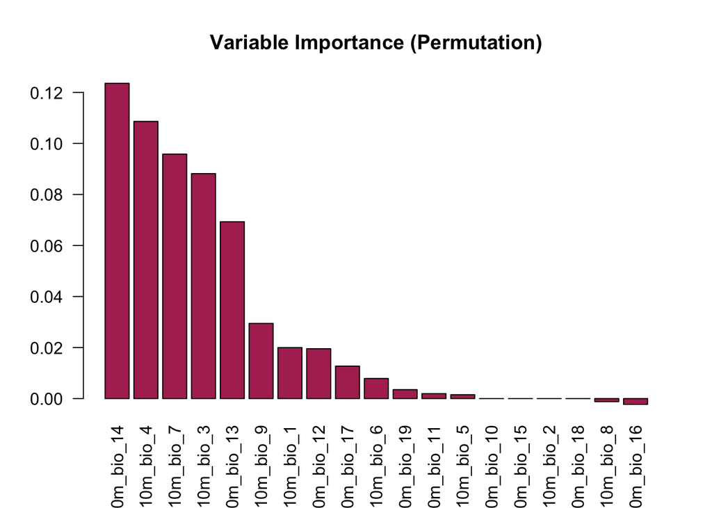

```r
barplot(imp, las = 2, main = "Variable Importance (Permutation)",col="maroon")
```